# 7275_final

```python
import numpy as np
import pandas as pd
import matplotlib.pyplot as plt
import seaborn as sns
import numpy as np
import matplotlib.pyplot as plt
```

```python
file_path = r"C:\Users\milan\Downloads\bank_data.xlsx"

df = pd.read_excel(file_path)
df.shape
print('The number of rows are:',df.shape[0])
print('The number of columns are:',df.shape[1])
df.info()
```

```
The number of rows are: 41188
The number of columns are: 21
<class 'pandas.core.frame.DataFrame'>
RangeIndex: 41188 entries, 0 to 41187
Data columns (total 21 columns):
 #   Column          Non-Null Count  Dtype
---  ------          --------------  -----
 0   age             41188 non-null  int64
 1   job             41188 non-null  object
 2   marital         41188 non-null  object
 3   education       41188 non-null  object
 4   default         41188 non-null  object
 5   housing         41188 non-null  object
 6   loan            41188 non-null  object
 7   contact         41188 non-null  object
 8   month           41188 non-null  object
 9   day_of_week     41188 non-null  object
 10  duration        41188 non-null  int64
 11  campaign        41188 non-null  int64
 12  pdays           41188 non-null  int64
 13  previous        41188 non-null  int64
 14  poutcome        41188 non-null  object
 15  emp.var.rate    41188 non-null  float64
 16  cons.price.idx  41188 non-null  float64
 17  cons.conf.idx   41188 non-null  float64
 18  euribor3m       41188 non-null  float64
 19  nr.employed     41188 non-null  float64
 20  y               41188 non-null  object
dtypes: float64(5), int64(5), object(11)
memory usage: 6.6+ MB
```

**Distribution of Target Variable (y):** Understanding the balance between the classes (subscribed vs. not subscribed).

**Univariate Analysis:** Analyzing the distribution of individual features.

**Bivariate Analysis:** Exploring the relationship between the features and the target variable.

**Correlation Analysis:** Checking if there are any highly correlated features.

```python
df.isnull().sum()
```

```
age               0
job               0
marital           0
education         0
default           0
housing           0
loan              0
contact           0
month             0
day_of_week       0
duration          0
campaign          0
pdays             0
previous          0
poutcome          0
emp.var.rate      0
cons.price.idx    0
cons.conf.idx     0
euribor3m         0
nr.employed       0
y                 0
dtype: int64
```

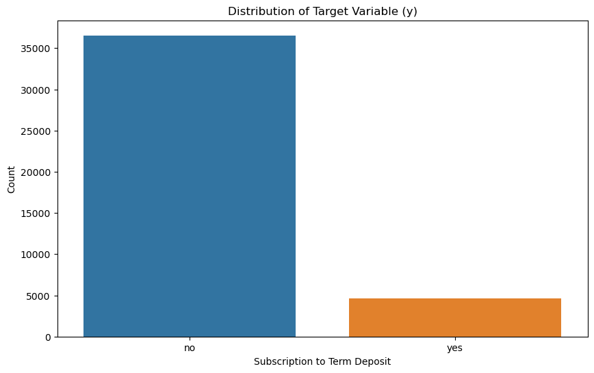

```python
# Distribution of the target variable 'y'
plt.figure(figsize=(10, 6))
sns.countplot(x='y', data=df)
plt.title('Distribution of Target Variable (y)')
plt.xlabel('Subscription to Term Deposit')
plt.ylabel('Count')
plt.show()
```

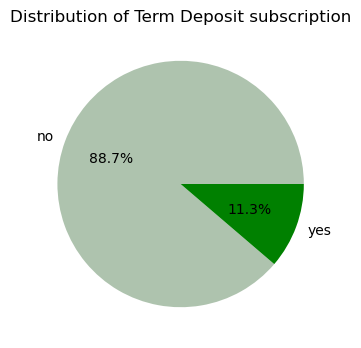

```python
term_deposit_count = df['y'].value_counts()
plt.figure(figsize=(4, 4))
plt.pie(term_deposit_count, labels=term_deposit_count.index,
autopct='%1.1f%%', colors=['#AEC3AE', 'green'])
plt.title('Distribution of Term Deposit subscription')
plt.show()
```

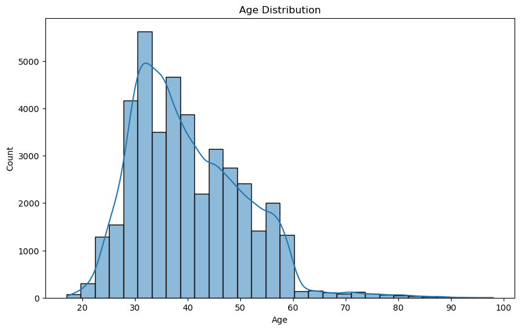

```python
plt.figure(figsize=(10, 6))
sns.histplot(df['age'], bins=30, kde=True)
plt.title('Age Distribution')
plt.xlabel('Age')
plt.ylabel('Count')
plt.show()
```

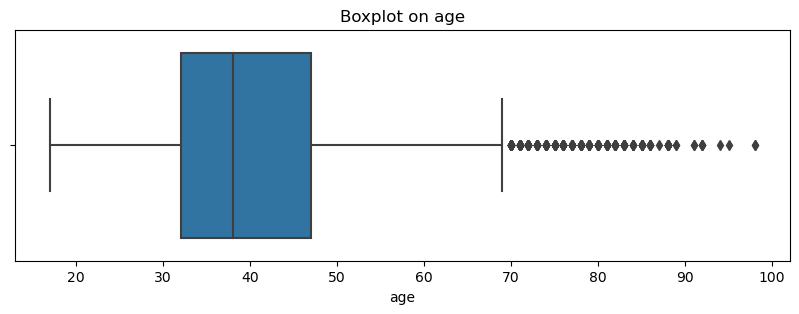

```python
plt.figure(figsize=(10, 3))
sns.boxplot(x=df.age, showfliers=True, showbox=True, whis=1.5)
plt.title('Boxplot on age')
plt.show()
```

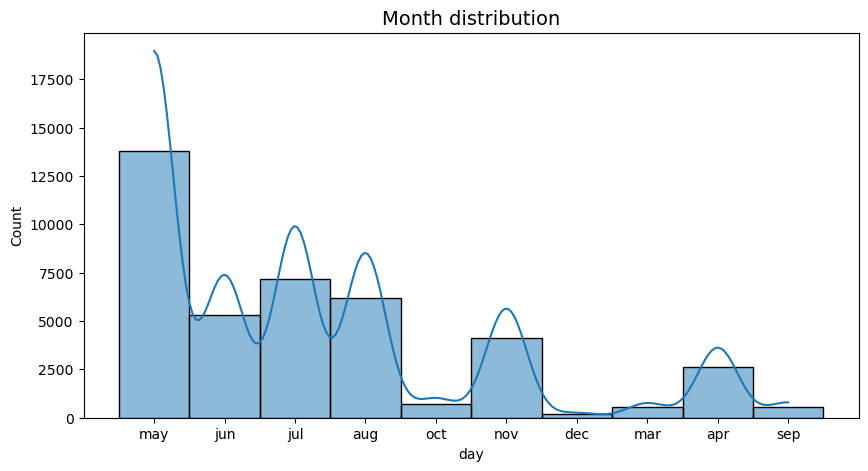

```python
plt.figure(figsize=(10, 5))
sns.histplot(data=df, x='month', kde=True)
plt.title('Month distribution', fontsize=14)
plt.xlabel('day')
plt.ylabel('Count')
plt.show()
```

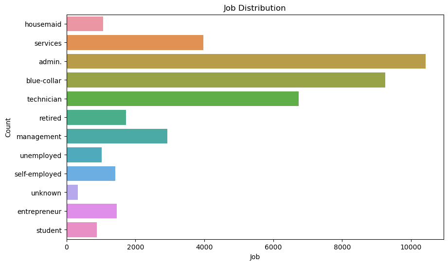

```python
plt.figure(figsize=(10, 6))
sns.countplot(y='job', data=df)
plt.title('Job Distribution')
plt.xlabel('Job')
plt.ylabel('Count')
plt.show()
```

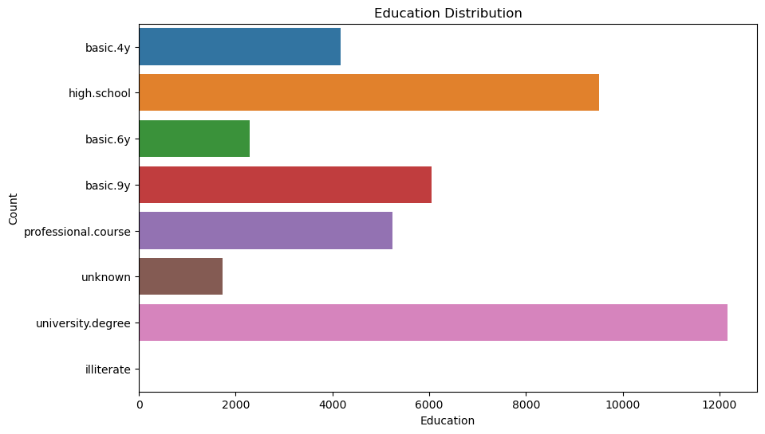

```python
plt.figure(figsize=(10, 6))
sns.countplot(y='education', data=df)
plt.title('Education Distribution')
plt.xlabel('Education')
plt.ylabel('Count')
plt.show()
```

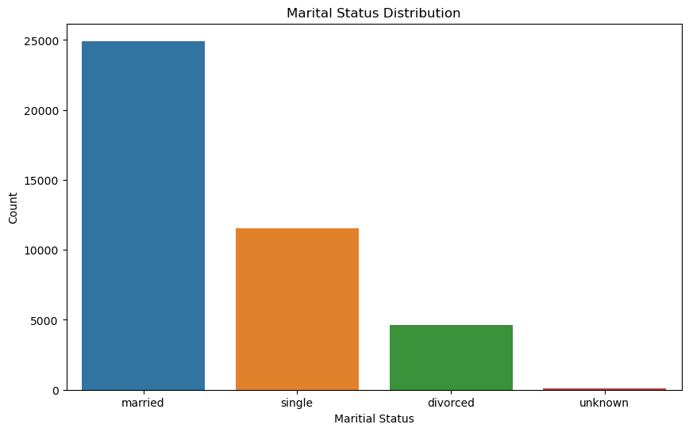

```python
plt.figure(figsize=(10, 6))
sns.countplot(x='marital',data=df)
plt.title('Marital Status Distribution')
plt.xlabel('Maritial Status')
plt.ylabel('Count')
plt.show()
```

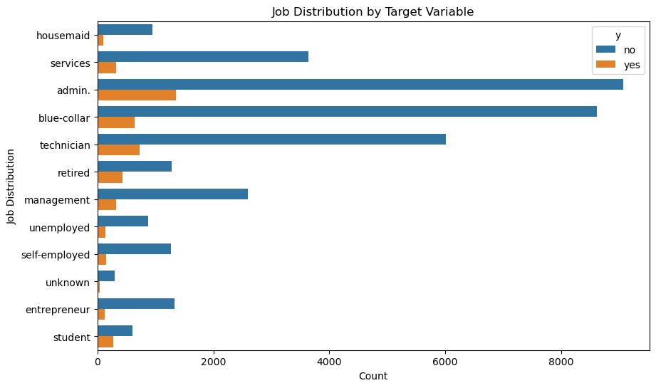

```python
plt.figure(figsize=(10, 6))
sns.countplot(y='job', hue='y',data=df)
plt.title('Job Distribution by Target Variable')
plt.ylabel('Job Distribution')
plt.xlabel('Count')
plt.show()
```

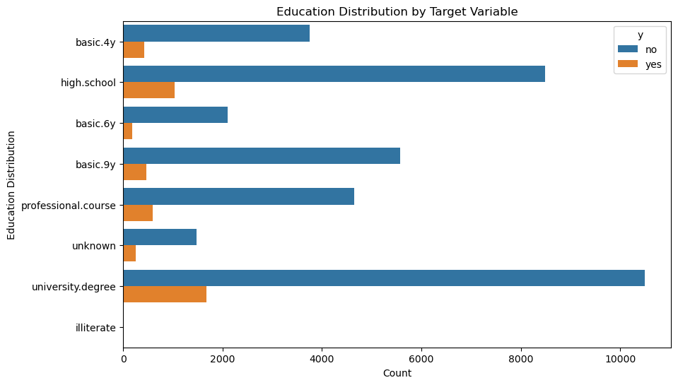

```python
plt.figure(figsize=(10, 6))
sns.countplot(y='education', hue='y',data=df)
plt.title('Education Distribution by Target Variable')
plt.ylabel('Education Distribution')
plt.xlabel('Count')
plt.show()
```

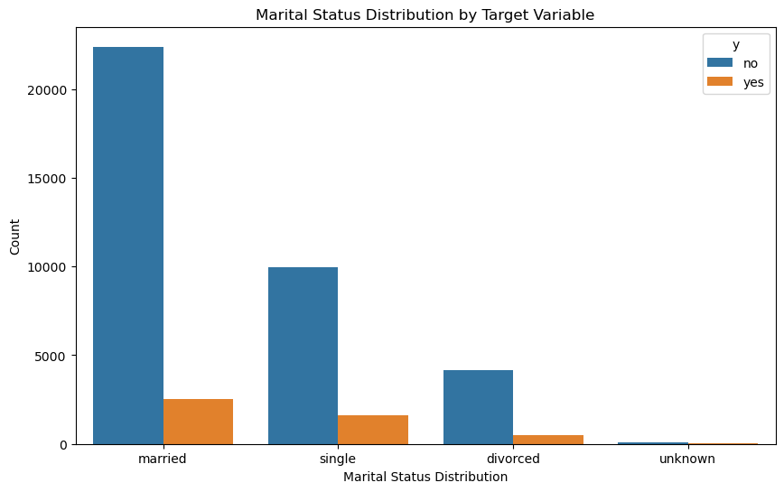

```python
plt.figure(figsize=(10, 6))
sns.countplot(x='marital', hue='y',data=df)
plt.title('Marital Status Distribution by Target Variable')
plt.xlabel('Marital Status Distribution')
plt.ylabel('Count')
plt.show()
```

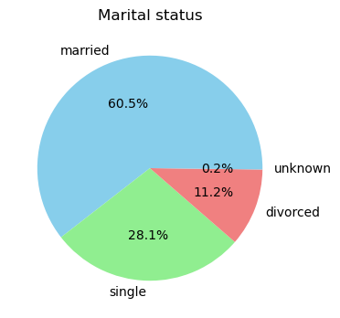

```python
marital_counts = df['marital'].value_counts()
plt.figure(figsize=(4, 4))
plt.pie(marital_counts, labels=marital_counts.index,
autopct='%1.1f%%', colors=['skyblue', 'lightgreen', 'lightcoral'])
plt.title('Marital status')
plt.show()
```

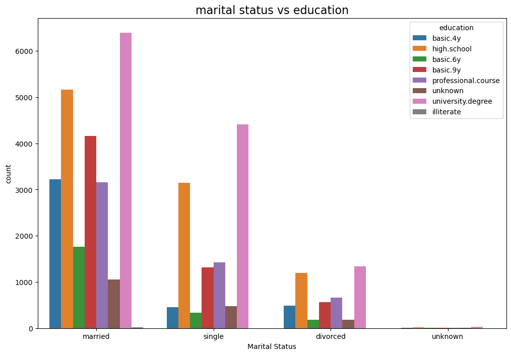

```python
plt.figure(figsize=(12,8))
sns.countplot(data=df, x=df.marital, hue=df.education)
plt.title('marital status vs education', fontsize=16)
plt.xlabel('Marital Status')
plt.show()
```

```
['no' 'unknown' 'yes']
```

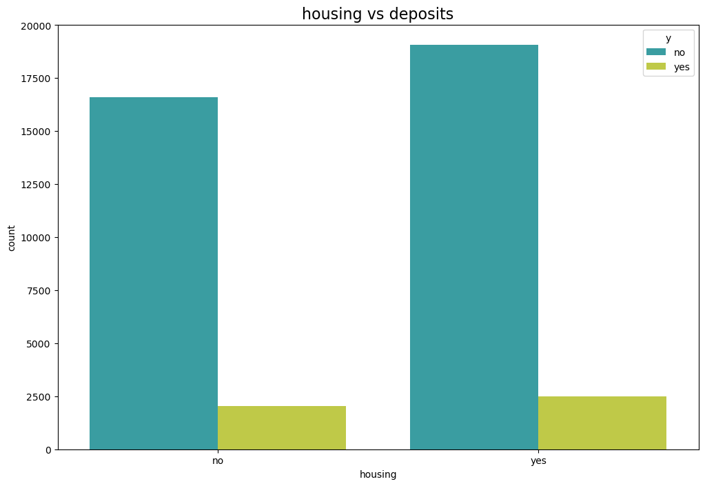

```python
df = df[df['housing'] != 'unknown']
print(df.default.unique())
plt.figure(figsize=(12,8))
sns.countplot(data=df, x=df.housing, hue=df['y'],palette=['#29ADB2', '#D2DE32'])
plt.title('housing vs deposits', fontsize=16)
plt.xlabel('housing')
plt.show()
```

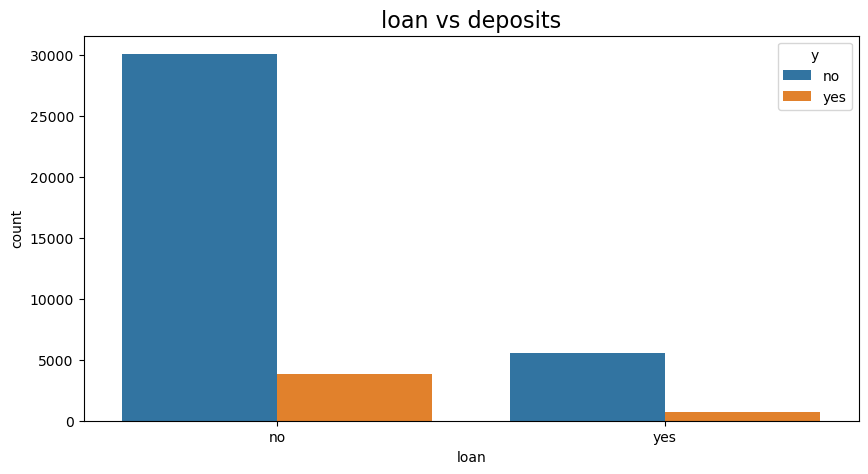

```python
plt.figure(figsize=(10,5))
sns.countplot(data=df, x=df.loan, hue=df['y'])
plt.title('loan vs deposits', fontsize=16)
plt.xlabel('loan')
plt.show()
```

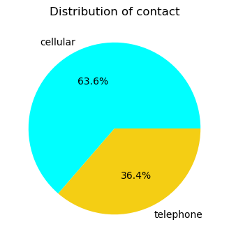

```python
marital_counts = df['contact'].value_counts()
plt.figure(figsize=(4, 4))
plt.pie(marital_counts, labels=marital_counts.index,
autopct='%1.1f%%', colors=['aqua', '#F4CE14'])
plt.title('Distribution of contact')
plt.show()
```

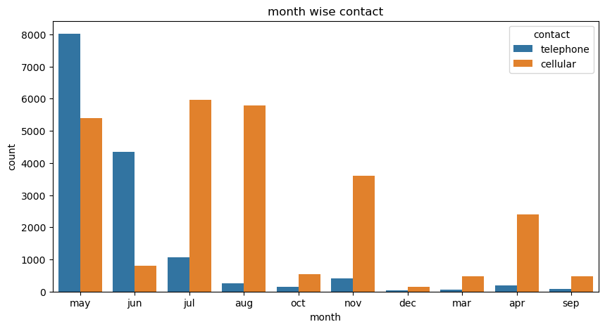

```python
plt.figure(figsize=(10, 5))
sns.countplot(data=df, x=df.month, hue=df['contact'])
plt.title('month wise contact')
plt.show()
```

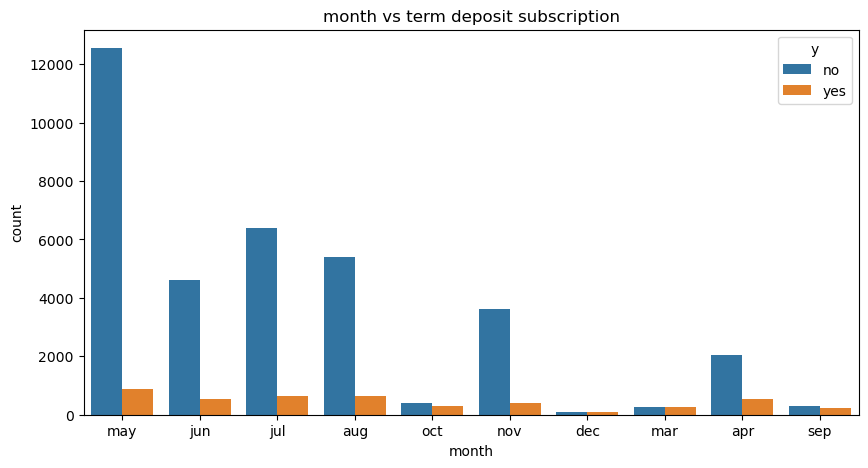

```python
plt.figure(figsize=(10, 5))
sns.countplot(data=df, x=df.month, hue=df['y'])
plt.title('month vs term deposit subscription')
plt.show()
```

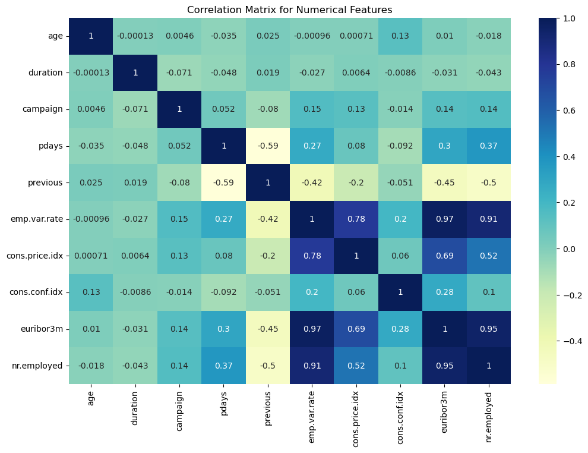

```python
numerical_features = df.select_dtypes(include=['int64', 'float64']).columns
correlation_matrix = df[numerical_features].corr()

# Plotting the correlation matrix
plt.figure(figsize=(12, 8))
sns.heatmap(correlation_matrix, annot=True, cmap='YlGnBu')
plt.title('Correlation Matrix for Numerical Features')
plt.show()
```

***Identified Highly Correlated Features***

**The analysis reveals the following pairs of highly correlated features:**

euribor3m and emp.var.rate with a correlation coefficient of approximately 0.97. nr.employed and euribor3m with a correlation coefficient of about 0.95. nr.employed and emp.var.rate with a correlation coefficient around 0.91. cons.price.idx and emp.var.rate with a correlation coefficient of about 0.78.

**Analyzing Redundancy**

euribor3m, emp.var.rate, and nr.employed: These three features are highly interrelated. Since they all are economic indicators, it's likely that they carry similar information regarding the economic condition during the time of the campaign.

**cons.price.idx and emp.var.rate:** Although correlated, the consumer price index (cons.price.idx) and the employment variation rate (emp.var.rate) may capture different aspects of the economy.

**Analyzing Correlation Among Economic Indicators:**

The high correlations among euribor3m, emp.var.rate, and nr.employed suggest that these indicators move together. This might be due to their connection to the broader economic situation, which impacts both employment and interest rates.

```python
# Identifying Highly Correlated Features
# We use a threshold of 0.75 for high correlation
high_corr_threshold = 0.75
highly_correlated_pairs = []

for i in range(len(correlation_matrix.columns)):
    for j in range(i):
        if abs(correlation_matrix.iloc[i, j]) > high_corr_threshold:
            highly_correlated_pairs.append((correlation_matrix.columns[i], correlation_matrix.columns[j], correlation_matrix.iloc[i, j]))

# Creating a DataFrame for better visualization
high_corr_df = pd.DataFrame(highly_correlated_pairs, columns=['Feature 1', 'Feature 2', 'Correlation Coefficient'])
high_corr_df.sort_values(by='Correlation Coefficient', ascending=False, inplace=True)

high_corr_df
```

|  | Feature 1 | Feature 2 | Correlation Coefficient |
| --- | --- | --- | --- |
| 1 | euribor3m | emp.var.rate | 0.972249 |
| 3 | nr.employed | euribor3m | 0.945243 |
| 2 | nr.employed | emp.var.rate | 0.907141 |
| 0 | cons.price.idx | emp.var.rate | 0.775032 |

```python
# Creating a composite economic indicator
df['composite_economic_indicator'] = df[['euribor3m', 'emp.var.rate', 'nr.employed']].mean(axis=1)

# Implementing Binning for the 'age' feature
# Defining age bins
age_bins = [0, 30, 40, 50, 60, 100]
age_labels = ['<30', '30-40', '40-50', '50-60', '>60']

# Creating a new column for binned age
df['age_group'] = pd.cut(df['age'], bins=age_bins, labels=age_labels, right=False)

# Displaying the first few rows of the modified dataset
df[['age', 'age_group', 'composite_economic_indicator']].head()
#ank_data.head()
```

|  | age | age_group | composite_economic_indicator |
| --- | --- | --- | --- |
| 0 | 56 | 50-60 | 1732.319 |
| 1 | 57 | 50-60 | 1732.319 |
| 2 | 37 | 30-40 | 1732.319 |
| 3 | 40 | 40-50 | 1732.319 |
| 4 | 56 | 50-60 | 1732.319 |

```python
# Check if categorical columns have nulls
categorical = df.select_dtypes(include='object').columns

for x in categorical:
    if df[x].isnull().any() or (df[x] == 'unknown').any():
        print("There are nulls", x)
    else:
        print("No Nulls in", x)

# Check if numerical columns have nulls
categorical = df.select_dtypes(include=['int64', 'float64']).columns

for x in categorical:
    if df[x].isnull().any() or (df[x] == 'unknown').any():
        print("There are nulls", x)
    else:
        print("No Nulls in", x)
```

```
There are nulls job
There are nulls marital
There are nulls education
There are nulls default
No Nulls in housing
No Nulls in loan
No Nulls in contact
No Nulls in month
No Nulls in day_of_week
No Nulls in poutcome
No Nulls in y
No Nulls in age
No Nulls in duration
No Nulls in campaign
No Nulls in pdays
No Nulls in previous
No Nulls in emp.var.rate
No Nulls in cons.price.idx
No Nulls in cons.conf.idx
No Nulls in euribor3m
No Nulls in nr.employed
No Nulls in composite_economic_indicator
```

```python
df1 = df.copy()
df1 = df1[df1['job']!= 'unknown']
df1 = df1[df1['marital']!= 'unknown']
df1 = df1[df1['education']!='unknown']
df1 = df1[df1['default']!='unknown']
df1.drop(['duration'],axis=1, inplace=True)
```

```python
from scipy.stats import zscore
def remove_outliers(col, data):
    outlier_col = col + "_outliers"
    data[outlier_col] = data[col]
    data[outlier_col]= zscore(data[outlier_col])
    condition = (data[outlier_col]>3) | (data[outlier_col]<-3)
    print(data[condition].shape)
    data.drop(data[condition].index, axis = 0, inplace = True)
    data.drop(outlier_col, axis=1, inplace=True)

remove_outliers('pdays',df1 )
remove_outliers('previous', df1)
```

```
(1310, 23)
(345, 23)
```

```python
x = ['job', 'marital', 'education','housing', 'loan','default']

for column in x:
    mode_value = df1[column].mode().iloc[0]  # .mode() returns a Series, use .iloc[0] to get the first mode
    unknown_count = (df1[column] == 'unknown').sum()
    print(f"{column} - Mode:{mode_value}, Unknowns: {unknown_count}")
```

```
job - Mode:admin., Unknowns: 0
marital - Mode:married, Unknowns: 0
education - Mode:university.degree, Unknowns: 0
housing - Mode:yes, Unknowns: 0
loan - Mode:no, Unknowns: 0
default - Mode:no, Unknowns: 0
```

```python
# Transform 'pdays' to a binary feature where '1' indicates the client was previously contacted (pdays < 999)
# and '0' indicates the client was not previously contacted (pdays = 999)
df1['pdays_contacted'] = df1['pdays'].apply(lambda x: 0 if x == 999 else 1)

# Now, we can drop the original 'pdays' column
df1 = df1.drop('pdays', axis=1)
```

```python
# Get a list of numerical columns
numerical_columns = df1.select_dtypes(include=['number']).columns.tolist()

# Print the list of numerical columns
print("Numerical Features in the DataFrame:")
print(numerical_columns)
```

```
Numerical Features in the DataFrame:
['age', 'campaign', 'previous', 'emp.var.rate', 'cons.price.idx', 'cons.conf.idx', 'euribor3m', 'nr.employed', 'composite_economic_indicator', 'pdays_contacted']
```

Age: Keep. Age could influence financial decisions like term deposit subscriptions.

Job: Keep. Different jobs may have different financial needs and preferences.

Marital: Keep. Marital status might correlate with financial stability and decisions.

Education: Keep. Education level can influence financial understanding and decisions.

Default: Keep. Credit default history is a crucial factor in financial decision-making.

Housing: Keep. Indicates if the client has a housing loan, which might affect their decision.

Loan: Keep. Similar to housing, having a personal loan could influence the decision.

Contact: Keep. The contact method might impact the effectiveness of the marketing campaign.

Month: Keep. The time of year might influence financial decisions.

Day_of_week: Keep. Day of the week could have a subtle effect on client's responsiveness.

Duration: Consider Removing. This feature highly affects the output target (if duration=0 then 'y'=no). However, this is not known before a call is made and thus should not be included in a predictive model.

Campaign: Keep. Number of contacts performed during this campaign might be relevant.

Previous: Keep. Number of contacts performed before this campaign.

Poutcome: Keep. Outcome of the previous marketing campaign can be significant.

Composite Economic Indicator: Keep. Represents combined economic factors.

Age Group: Consider Removing. This is a binned version of 'age' and might be redundant.

```python
columns_to_drop = ['emp.var.rate', 'cons.price.idx', 'cons.conf.idx', 'euribor3m', 'nr.employed', 'age_group']
df2 = df1.drop(columns=columns_to_drop)
```

```python
df2.info()
```

```
<class 'pandas.core.frame.DataFrame'>
Index: 28833 entries, 0 to 41187
Data columns (total 16 columns):
 #   Column                        Non-Null Count  Dtype
---  ------                        --------------  -----
 0   age                           28833 non-null  int64
 1   job                           28833 non-null  object
 2   marital                       28833 non-null  object
 3   education                     28833 non-null  object
 4   default                       28833 non-null  object
 5   housing                       28833 non-null  object
 6   loan                          28833 non-null  object
 7   contact                       28833 non-null  object
 8   month                         28833 non-null  object
 9   day_of_week                   28833 non-null  object
 10  campaign                      28833 non-null  int64
 11  previous                      28833 non-null  int64
 12  poutcome                      28833 non-null  object
 13  y                             28833 non-null  object
 14  composite_economic_indicator  28833 non-null  float64
 15  pdays_contacted               28833 non-null  int64
dtypes: float64(1), int64(4), object(11)
memory usage: 3.7+ MB
```

```python
# Categorical columns for one-hot encoding
categorical_cols = ['job', 'marital', 'education', 'contact', 'month', 'day_of_week', 'poutcome']

# One-hot encoding for categorical variables
data_encoded = pd.get_dummies(df2, columns=categorical_cols, drop_first=True,dtype=int)

# Display the first few rows of the encoded data
print(data_encoded.head())
```

```
   age default housing loan  campaign  previous   y  \
0   56      no      no   no         1         0  no
2   37      no     yes   no         1         0  no
3   40      no      no   no         1         0  no
4   56      no      no  yes         1         0  no
6   59      no      no   no         1         0  no

   composite_economic_indicator  pdays_contacted  job_blue-collar  ...  \
0                      1732.319                0                0  ...
2                      1732.319                0                0  ...
3                      1732.319                0                0  ...
4                      1732.319                0                0  ...
6                      1732.319                0                0  ...

   month_mar  month_may  month_nov  month_oct  month_sep  day_of_week_mon  \
0          0          1          0          0          0                1
2          0          1          0          0          0                1
3          0          1          0          0          0                1
4          0          1          0          0          0                1
6          0          1          0          0          0                1

   day_of_week_thu  day_of_week_tue  day_of_week_wed  poutcome_nonexistent
0                0                0                0                     1
2                0                0                0                     1
3                0                0                0                     1
4                0                0                0                     1
6                0                0                0                     1

[5 rows x 42 columns]
```

```python
from sklearn.preprocessing import LabelEncoder

# Binary columns for label encoding
binary_cols = ['default', 'housing', 'loan', 'y']

# Label encoding for binary variables
label_enc = LabelEncoder()
for col in binary_cols:
    data_encoded[col] = label_enc.fit_transform(data_encoded[col])

# Display the first few rows of the encoded data
print(data_encoded.head())
```

```
   age  default  housing  loan  campaign  previous  y  \
0   56        0        0     0         1         0  0
2   37        0        1     0         1         0  0
3   40        0        0     0         1         0  0
4   56        0        0     1         1         0  0
6   59        0        0     0         1         0  0

   composite_economic_indicator  pdays_contacted  job_blue-collar  ...  \
0                      1732.319                0                0  ...
2                      1732.319                0                0  ...
3                      1732.319                0                0  ...
4                      1732.319                0                0  ...
6                      1732.319                0                0  ...

   month_mar  month_may  month_nov  month_oct  month_sep  day_of_week_mon  \
0          0          1          0          0          0                1
2          0          1          0          0          0                1
3          0          1          0          0          0                1
4          0          1          0          0          0                1
6          0          1          0          0          0                1

   day_of_week_thu  day_of_week_tue  day_of_week_wed  poutcome_nonexistent
0                0                0                0                     1
2                0                0                0                     1
3                0                0                0                     1
4                0                0                0                     1
6                0                0                0                     1

[5 rows x 42 columns]
```

```python
import pandas as pd
from sklearn.preprocessing import StandardScaler
# Identify numerical columns for standardization
numerical_cols = ['age', 'campaign', 'previous', 'composite_economic_indicator', 'pdays_contacted']

# Standardize numerical features
scaler = StandardScaler()
data_encoded[numerical_cols] = scaler.fit_transform(data_encoded[numerical_cols])

# Display the first few rows after standardization
print("\nData after standardizing numerical features:")
print(data_encoded.head())
data = data_encoded
```

```
Data after standardizing numerical features:
        age  default  housing  loan  campaign  previous  y  \
0  1.707492        0        0     0 -0.562042 -0.340589  0
2 -0.188811        0        1     0 -0.562042 -0.340589  0
3  0.110605        0        0     0 -0.562042 -0.340589  0
4  1.707492        0        0     1 -0.562042 -0.340589  0
6  2.006909        0        0     0 -0.562042 -0.340589  0

   composite_economic_indicator  pdays_contacted  job_blue-collar  ...  \
0                       0.34607              0.0                0  ...
2                       0.34607              0.0                0  ...
3                       0.34607              0.0                0  ...
4                       0.34607              0.0                0  ...
6                       0.34607              0.0                0  ...

   month_mar  month_may  month_nov  month_oct  month_sep  day_of_week_mon  \
0          0          1          0          0          0                1
2          0          1          0          0          0                1
3          0          1          0          0          0                1
4          0          1          0          0          0                1
6          0          1          0          0          0                1

   day_of_week_thu  day_of_week_tue  day_of_week_wed  poutcome_nonexistent
0                0                0                0                     1
2                0                0                0                     1
3                0                0                0                     1
4                0                0                0                     1
6                0                0                0                     1

[5 rows x 42 columns]
```

```python
data
```

|  | age | default | housing | loan | campaign | previous | y | composite_economic_indicator | pdays_contacted | job_blue-collar | ... | month_mar | month_may | month_nov | month_oct | month_sep | day_of_week_mon | day_of_week_thu | day_of_week_tue | day_of_week_wed | poutcome_nonexistent |
| --- | --- | --- | --- | --- | --- | --- | --- | --- | --- | --- | --- | --- | --- | --- | --- | --- | --- | --- | --- | --- | --- |
| 0 | 1.707492 | 0 | 0 | 0 | -0.562042 | -0.340589 | 0 | 0.346070 | 0.0 | 0 | ... | 0 | 1 | 0 | 0 | 0 | 1 | 0 | 0 | 0 | 1 |
| 2 | -0.188811 | 0 | 1 | 0 | -0.562042 | -0.340589 | 0 | 0.346070 | 0.0 | 0 | ... | 0 | 1 | 0 | 0 | 0 | 1 | 0 | 0 | 0 | 1 |
| 3 | 0.110605 | 0 | 0 | 0 | -0.562042 | -0.340589 | 0 | 0.346070 | 0.0 | 0 | ... | 0 | 1 | 0 | 0 | 0 | 1 | 0 | 0 | 0 | 1 |
| 4 | 1.707492 | 0 | 0 | 1 | -0.562042 | -0.340589 | 0 | 0.346070 | 0.0 | 0 | ... | 0 | 1 | 0 | 0 | 0 | 1 | 0 | 0 | 0 | 1 |
| 6 | 2.006909 | 0 | 0 | 0 | -0.562042 | -0.340589 | 0 | 0.346070 | 0.0 | 0 | ... | 0 | 1 | 0 | 0 | 0 | 1 | 0 | 0 | 0 | 1 |
| ... | ... | ... | ... | ... | ... | ... | ... | ... | ... | ... | ... | ... | ... | ... | ... | ... | ... | ... | ... | ... | ... |
| 41183 | 3.404185 | 0 | 1 | 0 | -0.562042 | -0.340589 | 1 | -2.885563 | 0.0 | 0 | ... | 0 | 0 | 1 | 0 | 0 | 0 | 0 | 0 | 0 | 1 |
| 41184 | 0.709438 | 0 | 0 | 0 | -0.562042 | -0.340589 | 0 | -2.885563 | 0.0 | 1 | ... | 0 | 0 | 1 | 0 | 0 | 0 | 0 | 0 | 0 | 1 |
| 41185 | 1.707492 | 0 | 1 | 0 | -0.201907 | -0.340589 | 0 | -2.885563 | 0.0 | 0 | ... | 0 | 0 | 1 | 0 | 0 | 0 | 0 | 0 | 0 | 1 |
| 41186 | 0.509827 | 0 | 0 | 0 | -0.562042 | -0.340589 | 1 | -2.885563 | 0.0 | 0 | ... | 0 | 0 | 1 | 0 | 0 | 0 | 0 | 0 | 0 | 1 |
| 41187 | 3.503990 | 0 | 1 | 0 | 0.158228 | 2.936089 | 0 | -2.885563 | 0.0 | 0 | ... | 0 | 0 | 1 | 0 | 0 | 0 | 0 | 0 | 0 | 0 |

28833 rows × 42 columns

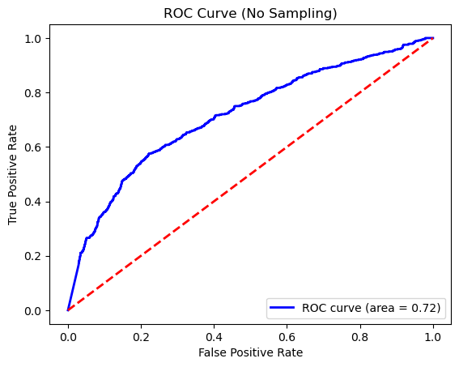

```
Classification Report:
              precision    recall  f1-score   support

           0       0.94      0.84      0.89      5199
           1       0.25      0.49      0.33       568

    accuracy                           0.80      5767
   macro avg       0.59      0.66      0.61      5767
weighted avg       0.87      0.80      0.83      5767

ROC-AUC Score: 0.7159172335416616
Confusion Matrix:
[[4359  840]
 [ 291  277]]
```

```python
import numpy as np
import matplotlib.pyplot as plt
from sklearn.metrics import classification_report, roc_auc_score, roc_curve, confusion_matrix
from sklearn.naive_bayes import GaussianNB
from sklearn.model_selection import train_test_split

# Split the data into features (X) and target (y)
X = data.drop('y', axis=1)
y = data['y']

# Split the data into training and testing sets
X_train, X_test, y_train, y_test = train_test_split(X, y, test_size=0.2, random_state=42)

# Initialize and train the Naive Bayes classifier
nb_model = GaussianNB()
nb_model.fit(X_train, y_train)

# Predict probabilities for the test set
y_pred_proba = nb_model.predict_proba(X_test)[:, 1]

# Predict classes for the test set
y_pred = nb_model.predict(X_test)

# Calculate classification report
classification_rep = classification_report(y_test, y_pred)

# Calculate ROC-AUC score
auc_roc_score = roc_auc_score(y_test, y_pred_proba)

# Plot ROC curve
fpr, tpr, _ = roc_curve(y_test, y_pred_proba)
plt.plot(fpr, tpr, color='blue', lw=2, label='ROC curve (area = %0.2f)' % auc_roc_score)
plt.plot([0, 1], [0, 1], color='red', lw=2, linestyle='--')
plt.xlabel('False Positive Rate')
plt.ylabel('True Positive Rate')
plt.title('ROC Curve (No Sampling)')
plt.legend(loc="lower right")
plt.show()

# Calculate confusion matrix
conf_matrix = confusion_matrix(y_test, y_pred)

# Display results
print("Classification Report:")
print(classification_rep)
print("ROC-AUC Score:", auc_roc_score)
print("Confusion Matrix:")
print(conf_matrix)
```

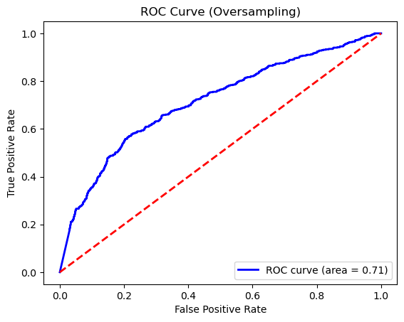

```
Classification Report (Oversampling):
              precision    recall  f1-score   support

           0       0.95      0.62      0.75      5199
           1       0.16      0.69      0.26       568

    accuracy                           0.62      5767
   macro avg       0.56      0.65      0.51      5767
weighted avg       0.87      0.62      0.70      5767

ROC-AUC Score (Oversampling): 0.7146536170281934
Confusion Matrix (Oversampling):
[[3206 1993]
 [ 177  391]]
```

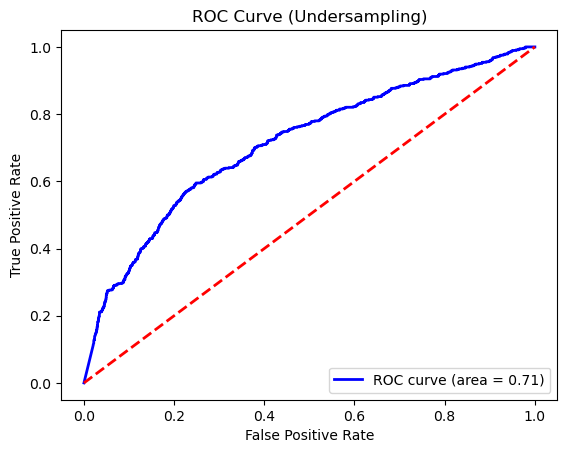

```
Classification Report (Undersampling):
              precision    recall  f1-score   support

           0       0.92      0.91      0.92      5199
           1       0.27      0.32      0.29       568

    accuracy                           0.85      5767
   macro avg       0.60      0.61      0.60      5767
weighted avg       0.86      0.85      0.85      5767

ROC-AUC Score (Undersampling): 0.712679036326054
Confusion Matrix (Undersampling):
[[4715  484]
 [ 387  181]]
```

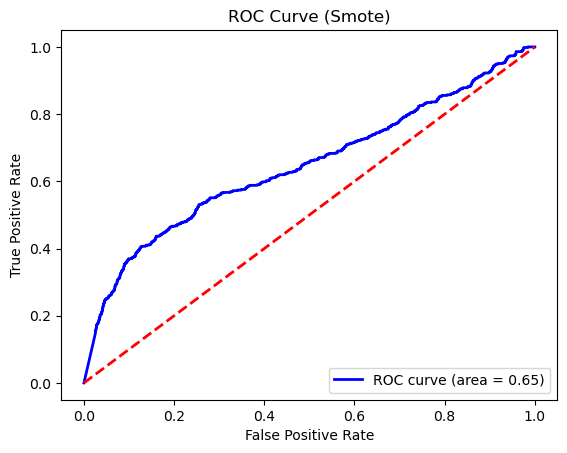

```
Classification Report (Smote):
              precision    recall  f1-score   support

           0       0.93      0.40      0.56      5199
           1       0.12      0.72      0.20       568

    accuracy                           0.43      5767
   macro avg       0.52      0.56      0.38      5767
weighted avg       0.85      0.43      0.52      5767

ROC-AUC Score (Smote): 0.6468279043369662
Confusion Matrix (Smote):
[[2071 3128]
 [ 160  408]]
```

```python
from imblearn.over_sampling import RandomOverSampler
from imblearn.under_sampling import RandomUnderSampler
from imblearn.over_sampling import SMOTE
from sklearn.metrics import classification_report, roc_auc_score, confusion_matrix, roc_curve
from sklearn.naive_bayes import GaussianNB

# Define a function to train and evaluate Naive Bayes classifier with different sampling techniques
def train_evaluate_with_sampling(X_train, X_test, y_train, y_test, sampling_method):
    if sampling_method == 'oversampling':
        # Oversampling with RandomOverSampler
        oversampler = RandomOverSampler(random_state=42)
        X_train_resampled, y_train_resampled = oversampler.fit_resample(X_train, y_train)
    elif sampling_method == 'undersampling':
        # Undersampling with RandomUnderSampler
        undersampler = RandomUnderSampler(random_state=42)
        X_train_resampled, y_train_resampled = undersampler.fit_resample(X_train, y_train)
    elif sampling_method == 'smote':
        # SMOTE
        smote = SMOTE(random_state=42)
        X_train_resampled, y_train_resampled = smote.fit_resample(X_train, y_train)
    else:
        # No sampling
        X_train_resampled, y_train_resampled = X_train, y_train

    # Initialize and train the Naive Bayes classifier
    nb_model = GaussianNB()
    nb_model.fit(X_train_resampled, y_train_resampled)

    # Predict probabilities for the test set
    y_pred_proba = nb_model.predict_proba(X_test)[:, 1]

    # Predict classes for the test set
    y_pred = nb_model.predict(X_test)

    # Calculate classification report
    classification_rep = classification_report(y_test, y_pred)

    # Calculate ROC-AUC score
    auc_roc_score = roc_auc_score(y_test, y_pred_proba)

    # Plot ROC curve
    fpr, tpr, _ = roc_curve(y_test, y_pred_proba)
    plt.plot(fpr, tpr, color='blue', lw=2, label='ROC curve (area = %0.2f)' % auc_roc_score)
    plt.plot([0, 1], [0, 1], color='red', lw=2, linestyle='--')
    plt.xlabel('False Positive Rate')
    plt.ylabel('True Positive Rate')
    plt.title('ROC Curve (' + sampling_method.capitalize() + ')')
    plt.legend(loc="lower right")
    plt.show()

    # Calculate confusion matrix
    conf_matrix = confusion_matrix(y_test, y_pred)

    # Display results
    print("Classification Report (" + sampling_method.capitalize() + "):")
    print(classification_rep)
    print("ROC-AUC Score (" + sampling_method.capitalize() + "):", auc_roc_score)
    print("Confusion Matrix (" + sampling_method.capitalize() + "):")
    print(conf_matrix)

# Train and evaluate Naive Bayes classifier with oversampling
train_evaluate_with_sampling(X_train, X_test, y_train, y_test, 'oversampling')

# Train and evaluate Naive Bayes classifier with undersampling
train_evaluate_with_sampling(X_train, X_test, y_train, y_test, 'undersampling')

# Train and evaluate Naive Bayes classifier with SMOTE
train_evaluate_with_sampling(X_train, X_test, y_train, y_test, 'smote')
```

```
Confusion Matrix (Oversampling):
[[3206 1993]
 [ 177  391]]
```

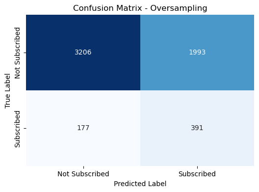

```
Confusion Matrix (Undersampling):
[[4715  484]
 [ 387  181]]
```

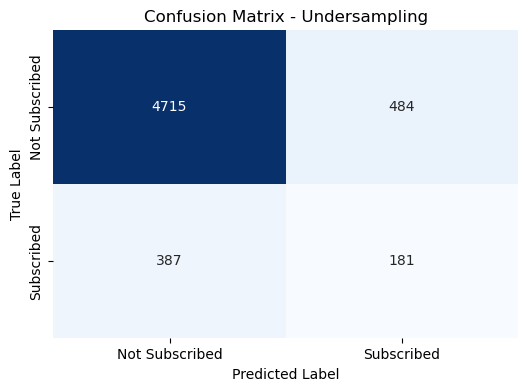

```
Confusion Matrix (Smote):
[[2071 3128]
 [ 160  408]]
```

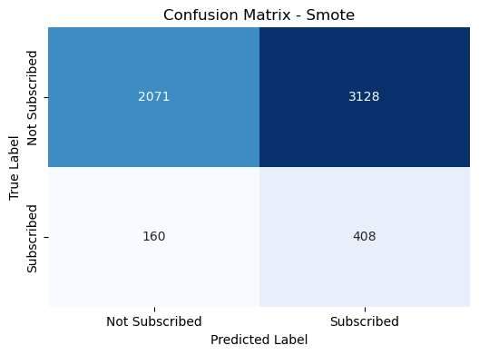

```
Confusion Matrix (No sampling):
[[4359  840]
 [ 291  277]]
```

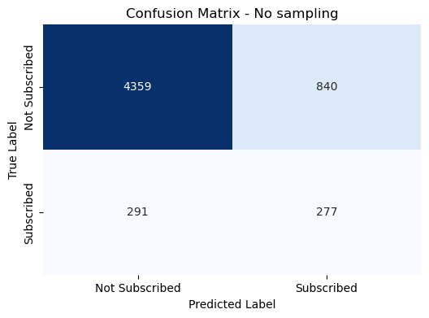

```python
import numpy as np
import seaborn as sns

# Define a function to train and evaluate Naive Bayes classifier with different sampling techniques
def train_evaluate_with_sampling(X_train, X_test, y_train, y_test, sampling_method):
    if sampling_method == 'oversampling':
        # Oversampling with RandomOverSampler
        oversampler = RandomOverSampler(random_state=42)
        X_train_resampled, y_train_resampled = oversampler.fit_resample(X_train, y_train)
    elif sampling_method == 'undersampling':
        # Undersampling with RandomUnderSampler
        undersampler = RandomUnderSampler(random_state=42)
        X_train_resampled, y_train_resampled = undersampler.fit_resample(X_train, y_train)
    elif sampling_method == 'smote':
        # SMOTE
        smote = SMOTE(random_state=42)
        X_train_resampled, y_train_resampled = smote.fit_resample(X_train, y_train)
    else:
        # No sampling
        X_train_resampled, y_train_resampled = X_train, y_train

    # Initialize and train the Naive Bayes classifier
    nb_model = GaussianNB()
    nb_model.fit(X_train_resampled, y_train_resampled)

    # Predict classes for the test set
    y_pred = nb_model.predict(X_test)

    # Calculate confusion matrix
    conf_matrix = confusion_matrix(y_test, y_pred)

    # Display results
    print("Confusion Matrix (" + sampling_method.capitalize() + "):")
    print(conf_matrix)

    # Plot heatmap
    plt.figure(figsize=(6, 4))
    sns.heatmap(conf_matrix, annot=True, cmap='Blues', fmt='g', cbar=False,
                xticklabels=['Not Subscribed', 'Subscribed'], yticklabels=['Not Subscribed', 'Subscribed'])
    plt.xlabel('Predicted Label')
    plt.ylabel('True Label')
    plt.title('Confusion Matrix - ' + sampling_method.capitalize())
    plt.show()

# Train and evaluate Naive Bayes classifier with oversampling
train_evaluate_with_sampling(X_train, X_test, y_train, y_test, 'oversampling')

# Train and evaluate Naive Bayes classifier with undersampling
train_evaluate_with_sampling(X_train, X_test, y_train, y_test, 'undersampling')

# Train and evaluate Naive Bayes classifier with SMOTE
train_evaluate_with_sampling(X_train, X_test, y_train, y_test, 'smote')

# Train and evaluate Naive Bayes classifier without sampling
train_evaluate_with_sampling(X_train, X_test, y_train, y_test, 'no sampling')
```

Naive Bayes assumes that features are conditionally independent given the target variable and estimates class-conditional means and variances for continuous features, hence we do not try to find the features